# Spatial data

Ted Hart

August 11, 2014

`spocc` also allows for interaction with other spatial objects with the ability to transform a `spocc` dataframe into a spatial points object. We can easily grab some spatial data using an rOpenSci package currently in development called `prism`. So first let’s grab some temperature data and load it up.

```r
#install_github("prism", "ropensci")
library(raster)
library(prism)
library(spocc)
library(taxize)
options(prism.path = "~/prismtmp")
get_prism_normals(type="tmean", annual=TRUE, resolution = "4km",keepZip=F)
ls_prism_data()
```

```
## [1] "PRISM_tmean_30yr_normal_4kmM2_annual_bil"
## [2] "PRISM_tmean_30yr_normal_800mM2_annual_bil"
```

```r
prismfile <- ls_prism_data(absPath=T)[1]
unprojDep <- raster(prismfile)
crs_str <- "+init=EPSG:4326 +proj=longlat +datum=WGS84 +no_defs +ellps=WGS84 +towgs84=0,0,0"
projDep <- projectRaster(from = unprojDep,crs=crs_str)
```

Next let’s grab some tree species that are distributed across the US.

```r
splist <- sort(c("Acer saccharum", "Abies balsamea", "Arbutus xalapensis", "Betula alleghaniensis", "Chilopsis linearis", "Conocarpus erectus", "Populus tremuloides", "Larix laricina"))
out <- occ(query = splist, from = c("bison"), limit = 100)
## scrub names
out <- fixnames(out, how = "query")
## Create a data frame of all data.
out_df <- occ2df(out)
```

Now we want to check and make sure that our points are actually on the map.

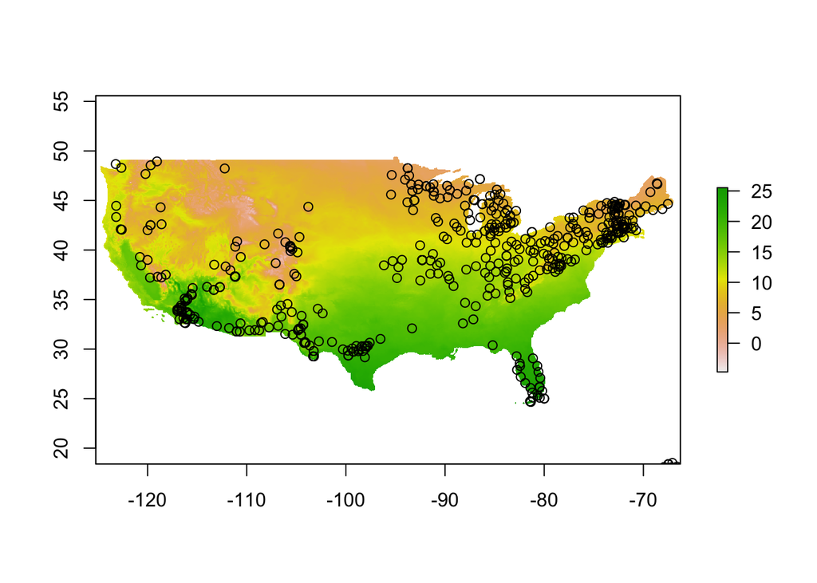

```r
plot(projDep)
points(out_df$longitude,out_df$latitude)
```

The last thing we’ll do is use `sci2comm` to convert our list of latin names into common names, convert our query to a spatial point object, and then grab the mean temperature and mean latitute of each species.

```r
library(plyr)
## Get common names
cname <- ldply(sci2comm(get_tsn(splist), db = "itis", simplify = TRUE), function(x) { return(x[1]) })[, 2]

#convert our query to a spatial object
sp_points <- occ_to_sp(out, coord_string = crs_str)

## Grab the mean temperature and
mtemp <- rep(NA,length(splist))
mlat <- rep(NA,length(splist))
for (i in 1:length(splist)) {
  tmp_sp <- sp_points[which(sp_points$name == splist[i]), ]
  mtemp[i] <- mean(unlist(extract(projDep,tmp_sp,buffer = 100)),na.rm=T)
  mlat[i] <- mean(coordinates(tmp_sp)[,2])
}
df <- data.frame(cbind(mtemp,mlat))
df$name <- cname
```

Lastly we can now plot mean temerature from our prism map vs mean latitude for each species. We’ll lable the point with the common name.

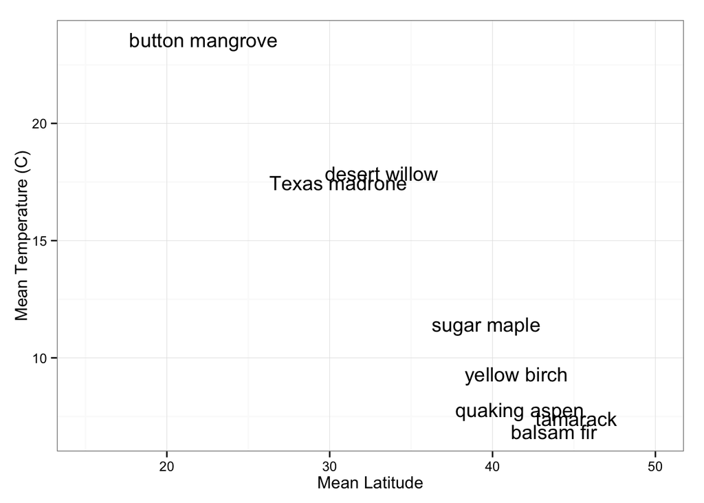

```r
ggplot(df, aes(x = mlat, y = mtemp, label = name)) +
  geom_text() +
  xlab("Mean Latitude") +
  ylab("Mean Temperature (C)") +
  theme_bw() +
  xlim(15, 50)
```

While above we had a nice quick and dirty plot to check out work, let’s consider making a nicer map wih `ggplot2`

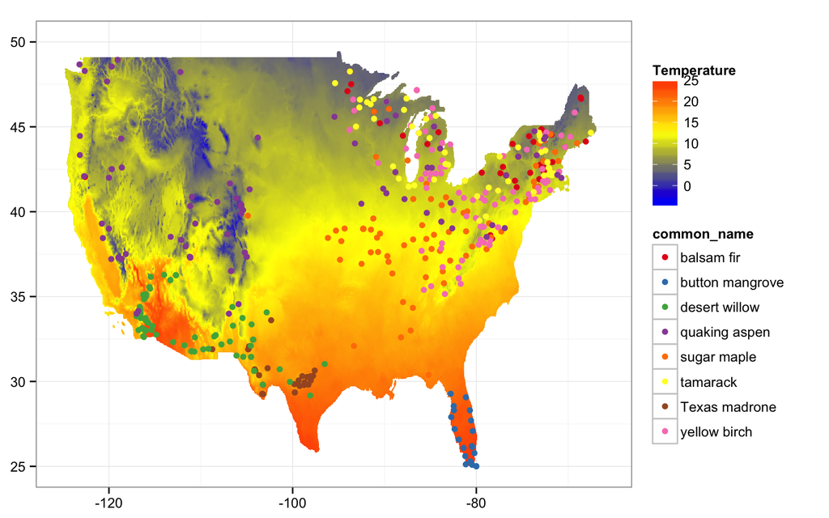

```r
## NOTE: this only works because I was sure to sort my species names alphabetically.
## Otherwise an insideous error would likely happen

out_df$common_name <- rep(cname,table(out_df$name))
gpoints <- rasterToPoints(projDep)
df = data.frame(gpoints)
colnames(df) = c("x", "y", "Temperature")


ggplot() + geom_tile(data = df, aes(x, y, fill=Temperature)) + geom_point(data=out_df,aes(x=longitude,y=latitude, group=common_name,colour=common_name)) + labs(x=NULL, y=NULL) +  scale_fill_gradient2(low="blue", mid = "yellow", high="red", midpoint = 12.5) + theme_bw() + xlim(-125,-66) + ylim(25,50)+scale_colour_brewer(palette="Set1")
```